# Tutorial 4- Local Regression & Kernel Regression

# 1 Introduction

## 1.1 Simple Smoothers in R

Local Averaging (Friedman’s “Super Smoother”):

```
supsmu(x, y, wt =, span = "cv", periodic = FALSE, bass = 0, trace = FALSE)
```

Local Regression (Cleveland’s LOESS):

```
loess(formula, data, weights, subset, na.action, model = FALSE,
         span = 0.75, enp.target, degree = 2,
         parametric = FALSE, drop.square = FALSE, normalize = TRUE,
         family = c("gaussian", "symmetric"),
         method = c("loess", "model.frame"),
         control = loess.control(...), ...)
```

Kernel Regression (Nadaraya and Watson’s Kernel Smoother):

```
ksmooth(x, y, kernel = c("box", "normal"), bandwidth = 0.5,
        range.x = range(x),
        n.points = max(100L, length(x)), x.points)
```

## 1.2 Need for NP Regression

```r
# Consider the dataset anscombe
anscombe
```

| x1 | x2 | x3 | x4 | y1 | y2 | y3 | y4 |
| --- | --- | --- | --- | --- | --- | --- | --- |
| 10 | 10 | 10 | 8 | 8.04 | 9.14 | 7.46 | 6.58 |
| 8 | 8 | 8 | 8 | 6.95 | 8.14 | 6.77 | 5.76 |
| 13 | 13 | 13 | 8 | 7.58 | 8.74 | 12.74 | 7.71 |
| 9 | 9 | 9 | 8 | 8.81 | 8.77 | 7.11 | 8.84 |
| 11 | 11 | 11 | 8 | 8.33 | 9.26 | 7.81 | 8.47 |
| 14 | 14 | 14 | 8 | 9.96 | 8.10 | 8.84 | 7.04 |
| 6 | 6 | 6 | 8 | 7.24 | 6.13 | 6.08 | 5.25 |
| 4 | 4 | 4 | 19 | 4.26 | 3.10 | 5.39 | 12.50 |
| 12 | 12 | 12 | 8 | 10.84 | 9.13 | 8.15 | 5.56 |
| 7 | 7 | 7 | 8 | 4.82 | 7.26 | 6.42 | 7.91 |

[output cut: 1 more lines]

```r
# Fit the linear regression model
lm1 <- lm(y1 ~ x1, data = anscombe)
lm2 <- lm(y2 ~ x2, data = anscombe)
lm3 <- lm(y3 ~ x3, data = anscombe)
lm4 <- lm(y4 ~ x4, data = anscombe)

# print coefficients
coef(lm1)
```

```
## (Intercept)          x1
##   3.0000909   0.5000909
```

```r
# check R-squared values
summary(lm1)$r.squared
```

```
## [1] 0.6665425
```

```r
summary(lm2)$r.squared
```

```
## [1] 0.666242
```

```r
summary(lm3)$r.squared
```

```
## [1] 0.666324
```

```r
summary(lm4)$r.squared
```

```
## [1] 0.6667073
```

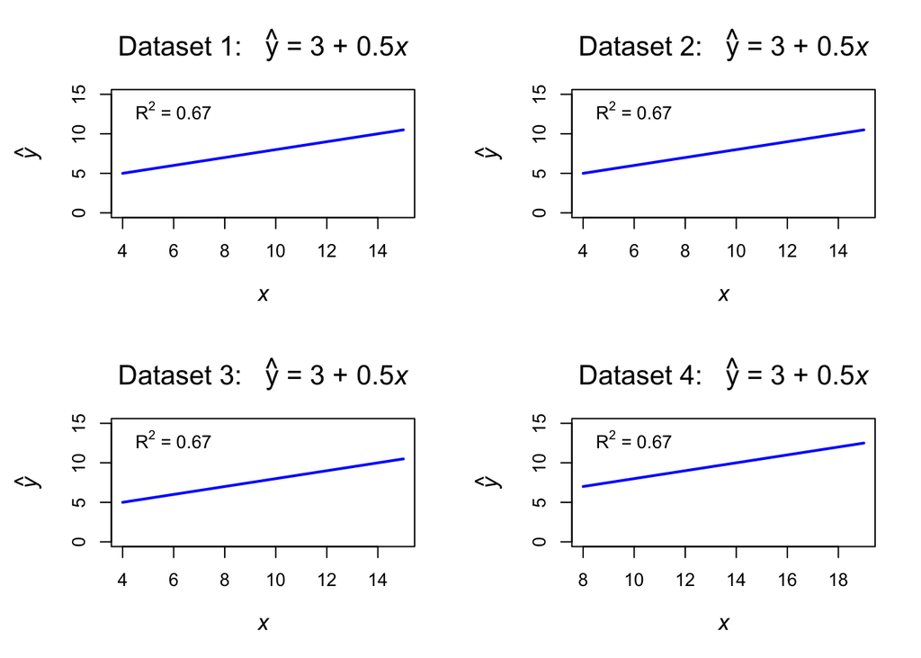

```r
# plot results
mods <- list(lm1, lm2, lm3, lm4)
par(mfrow = c(2, 2), mar = c(5, 5, 4, 2) + 0.1)
for(j in 1:4){
  xseq <- seq(4, 15, length.out = 20) + ifelse(j == 4, 4, 0)
  coefs <- coef(mods[[j]])
  title <- substitute("Dataset " * jj * ":   " * hat(y) * " = 3 + 0.5" * italic(x),
                      list(jj = j))
  plot(xseq, coefs[1] + coefs[2] * xseq, type = "l", ylim = c(0, 15),
     xlab = expression(italic(x)), ylab = expression(hat(italic(y))),
     main = title, lwd = 2, col = "blue", cex.lab = 1.25, cex.main = 1.5)
  text(6 + ifelse(j == 4, 4, 0), 13, expression(R^2 * " = 0.67"))
}
```

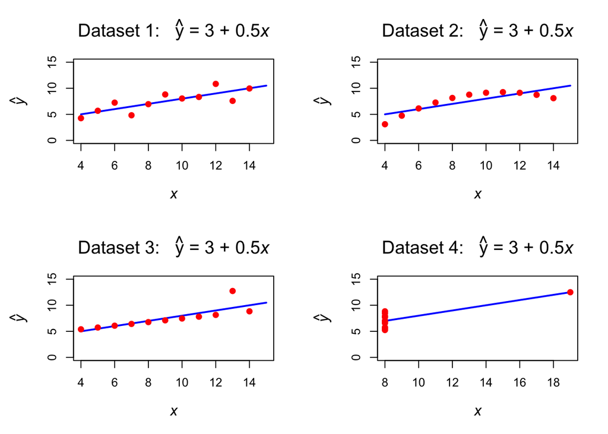

```r
# plot results with data
mods <- list(lm1, lm2, lm3, lm4)
par(mfrow = c(2, 2), mar = c(5, 5, 4, 2) + 0.1)
for(j in 1:4){
  xseq <- seq(4, 15, length.out = 20) + ifelse(j == 4, 4, 0)
  coefs <- coef(mods[[j]])
  title <- substitute("Dataset " * jj * ":   " * hat(y) * " = 3 + 0.5" * italic(x),
                      list(jj = j))
  plot(xseq, coefs[1] + coefs[2] * xseq, type = "l", ylim = c(0, 15),
     xlab = expression(italic(x)), ylab = expression(hat(italic(y))),
     main = title, lwd = 2, col = "blue", cex.lab = 1.25, cex.main = 1.5)
  points(anscombe[,c(j, j + 4)], pch = 19, col = "red")
}
```

One can readily seen that parametric regression models may not reveal “true” relationships in data.

## 1.3 Interetsed Model

Suppose we observe $n$ independent pairs of points $\{x_i,y_i\}_{i=1}^n$ with relationship
$$y_i=f(x_i)+\epsilon_i,$$
where $f(\cdot)$ is some unknown smooth function.

# 2 Local Averaging

To estimate the unknown function $f(\cdot)$, Friedman (1984) proposed the simple and powerful idea of local averaging. The local averaging estimate of the function $f(\cdot)$ evaluated at the point $x$ is constructed by taking an average of the $y_i$ values corresponding to $x_i$ values that are nearby the given $x$.

The local averaging estimate can be written as
$$\hat{f}(x)=\frac{\sum_{i=1}^ny_iw_i(x)}{\sum_{i=1}^nw_i(x)},$$
where the weights are defined such that $w_i(x)=1$ if the point $x_i$ is nearby the point $x$, and $w_i(x)=0$ otherwise.

## 2.1 How Close is Nearby?

To formalize the concept of nearby, Friedman proposed using the smallest symmetric window around $x_i$ that contains $sn$ observations, where $s\in(0,1]$. The parameter $s$ is called the span parameter, which controls the smoothness of the function estimate. As $s\to 0$ the function estimate becomes less smooth, and as $s\to1$ the function estimate becomes more smooth. The goal is to find the value of $s$ that provides a “reasonable” estimate of the unknown smooth function $f(\cdot)$.

## 2.2 Simulation

To get an understanding of the local averaging estimator, we will look at how the estimate is formed for the point $x^*=0.3$ using different values of the span parameter.

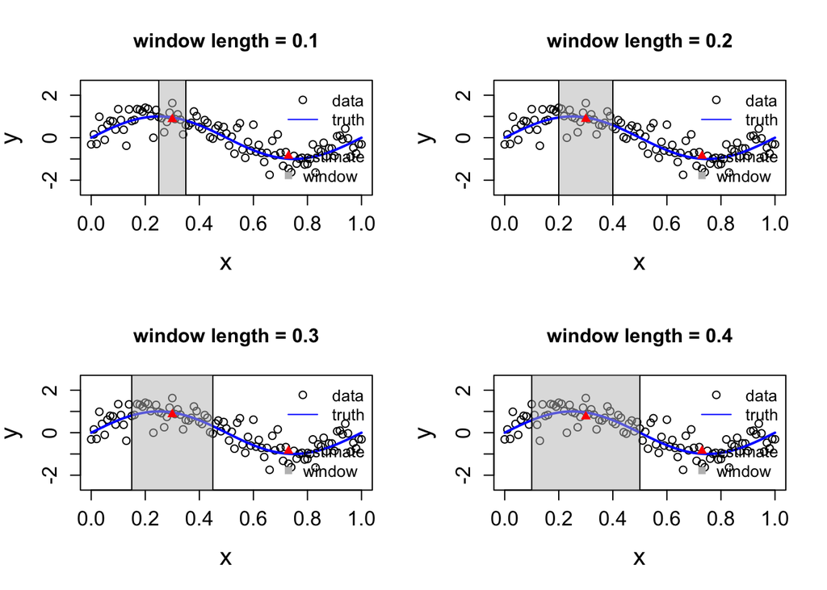

```r
# define function and data
set.seed(1)
n <- 101
x <- seq(0, 1, length.out = n)
fx <- sin(2 * pi * x)
y <- fx + rnorm(n, sd = 0.5)

# define x* and color for window
xstar <- 0.3
cols <- rgb(190/255, 190/255, 190/255, alpha = 0.5)

# set-up 2 x 2 subplot
par(mfrow = c(2,2))

# loop through window length (0.1, 0.2, 0.3, 0.4)
for(s in c(0.1, 0.2, 0.3, 0.4)){

  # plot data and true function
  plot(x, y, main = paste0("window length = ", s), ylim = c(-2.5, 2.5),
       cex.lab = 1.5, cex.axis = 1.25)
  lines(x, fx, col = "blue", lwd = 2)

  # plot window
  window <- c(xstar - s / 2, xstar + s / 2)
  rect(window[1], -3, window[2], 3, col = cols)

  # define weights
  w <- rep(0, n)
  w[x >= window[1] & x <= window[2]] <- 1

  # plot estimate
  ystar <- sum(y * w) / sum(w)
  points(xstar, ystar, pch = 17, col = "red", cex = 1)

  # add legend
  legend("topright", legend = c("data", "truth"),
         pch = c(1, NA), lty = c(NA, 1), col = c("black", "blue"), bty = "n")
  legend("bottomright", legend = c("estimate", "window"),
         pch = c(17, 15), col = c("red", "gray"), bty = "n")

}
```

Note that the estimate (denoted by the red triangle) is calculated by averaging all of the $y_i$ values that are within the local window (denoted by the gray box). The above example shows the window for the point $x^*=0.3$, but the same idea applies to other points. To form the function estimate at a different $x$ value, we would just slide the averaging window down the x-axis to be centered at the new $x$ value.. As a result, the local averaging estimator is sometimes referred to as a “moving average” estimator.

## 2.3 Selecting the Span

Typically the value of $s$ is determined using leave-one-out cross-validation, which can be done by the **supsmu** function.

# 3 Local Regression

## 3.1 Definition

The local linear regression estimate is given by
$$\hat{f}(x)=\hat{\beta}_0^{(x)}+\hat{\beta}_1^{(x)}x,$$
where $\hat{\beta}_0^{(x)}$ and $\hat{\beta}_1^{(x)}$ are the minimizers of the weighted least squares problem
$$\sum_{i=1}^n w_i(x) (y_i-\beta_0-\beta_1 x_i)^2$$
.

A popular weight function is the tricube function
$$w_i(x)=\begin{cases} (1-|x-x_i|^3)^3 & \textrm{if}~|x-x_i|<\delta_i\\
0&\textrm{otherwise}
\end{cases}$$
where $\delta_i$ is some scalar that is used to determine which points are close enough to the given $x$ to receive a non-zero weight.

The local polynomial regression estimate is given by
$$\hat{f}(x)=\hat{\beta}_0^{(x)}+\hat{\beta}_1^{(x)}x+\hat{\beta}_2^{(x)}x^2,$$
where $\hat{\beta}_0^{(x)}$, $\hat{\beta}_1^{(x)}$ and $\hat{\beta}_2^{(x)}$ are the minimizers of the weighted least squares problem
$$\sum_{i=1}^n w_i(x) (y_i-\beta_0-\beta_1 x_i-\beta_2 x_i^2)^2$$
.

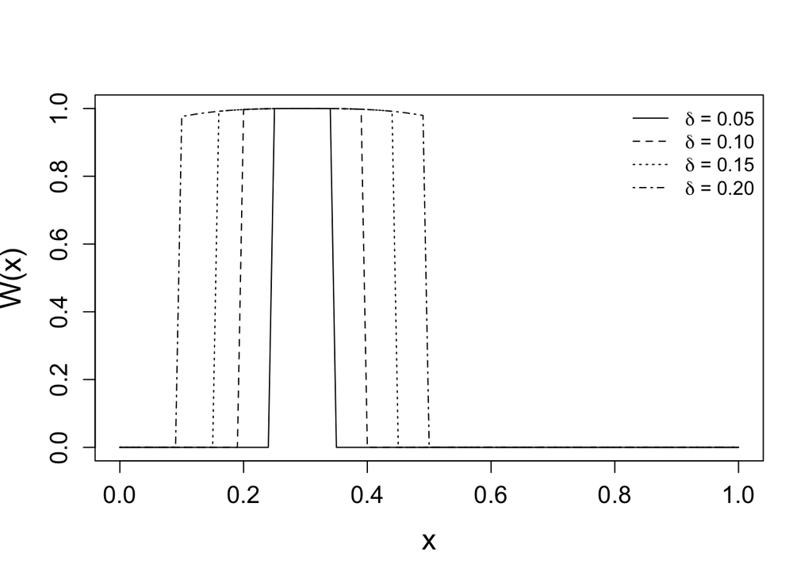

```r
# define tricube weight function
tricube <- function(x, delta = 0.1) {
  ifelse(abs(x) < delta, (1 - abs(x)^3)^3, 0)
}

# plot tricube weight function
xstar <- 0.3
plot(x, tricube(x - xstar, 0.1 / 2), t = "l", ylab = "W(x)",
     cex.lab = 1.5, cex.axis = 1.25)
deltas <- c(0.2, 0.3, 0.4)
for(k in 1:3){
  lines(x, tricube(x - xstar, deltas[k] / 2), lty = k + 1)
}
legend("topright", legend = c(expression(delta * " = 0.05"),
                              expression(delta * " = 0.10"),
                              expression(delta * " = 0.15"),
                              expression(delta * " = 0.20")),
       lty = 1:4, bty = "n")
```

## 3.2 Simulation

To get an understanding of the local regression estimator, we will look at how the estimate is formed for the point $x^*=0.3$ using different values of the span parameter.

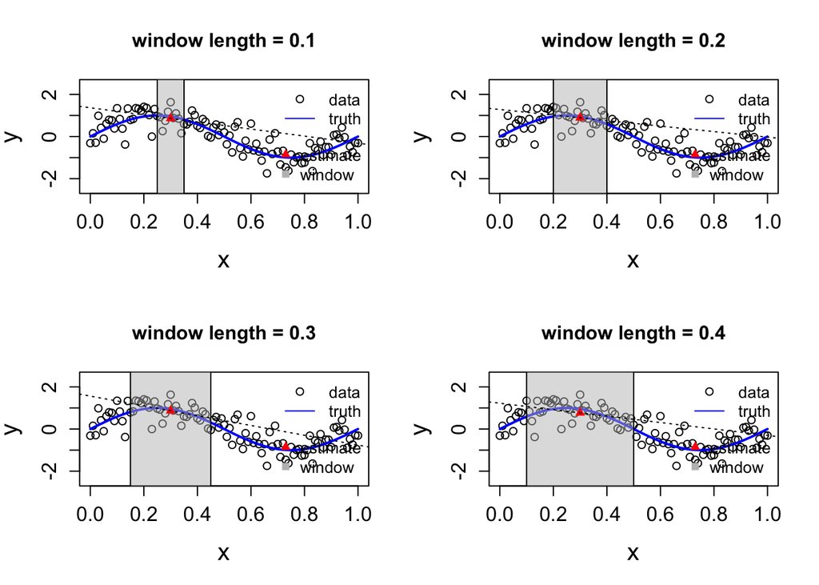

```r
# Local Linear Regression


# define function and data
set.seed(1)
n <- 101
x <- seq(0, 1, length.out = n)
fx <- sin(2 * pi * x)
y <- fx + rnorm(n, sd = 0.5)

# define x* and color for window
xstar <- 0.3
cols <- rgb(190/255,190/255,190/255,alpha=0.5)

# set-up 2 x 2 subplot
par(mfrow = c(2,2))

# loop through window length (0.1, 0.2, 0.3, 0.4)
for(s in c(0.1, 0.2, 0.3, 0.4)){

  # plot data and true function
  plot(x, y, main = paste0("window length = ", s), ylim = c(-2.5, 2.5),
       cex.lab = 1.5, cex.axis = 1.25)
  lines(x, fx, col = "blue", lwd = 2)

  # plot window
  window <- c(xstar - s / 2, xstar + s / 2)
  rect(window[1], -3, window[2], 3, col = cols)

  # define weights
  w <- tricube(x - xstar, delta = s / 2)

  # plot estimate
  X.w <- sqrt(w) * cbind(1, x)
  y.w <- sqrt(w) * y
  beta <- solve(crossprod(X.w)) %*% crossprod(X.w, y.w)
  ystar <- as.numeric(cbind(1, xstar) %*% beta)
  points(xstar, ystar, pch = 17, col = "red", cex = 1)

  # add regression line
  abline(beta, lty = 3)

  # add legend
  legend("topright", legend = c("data", "truth"),
         pch = c(1, NA), lty = c(NA, 1), col = c("black", "blue"), bty = "n")
  legend("bottomright", legend = c("estimate", "window"),
         pch = c(17, 15), col = c("red", "gray"), bty = "n")

}
```

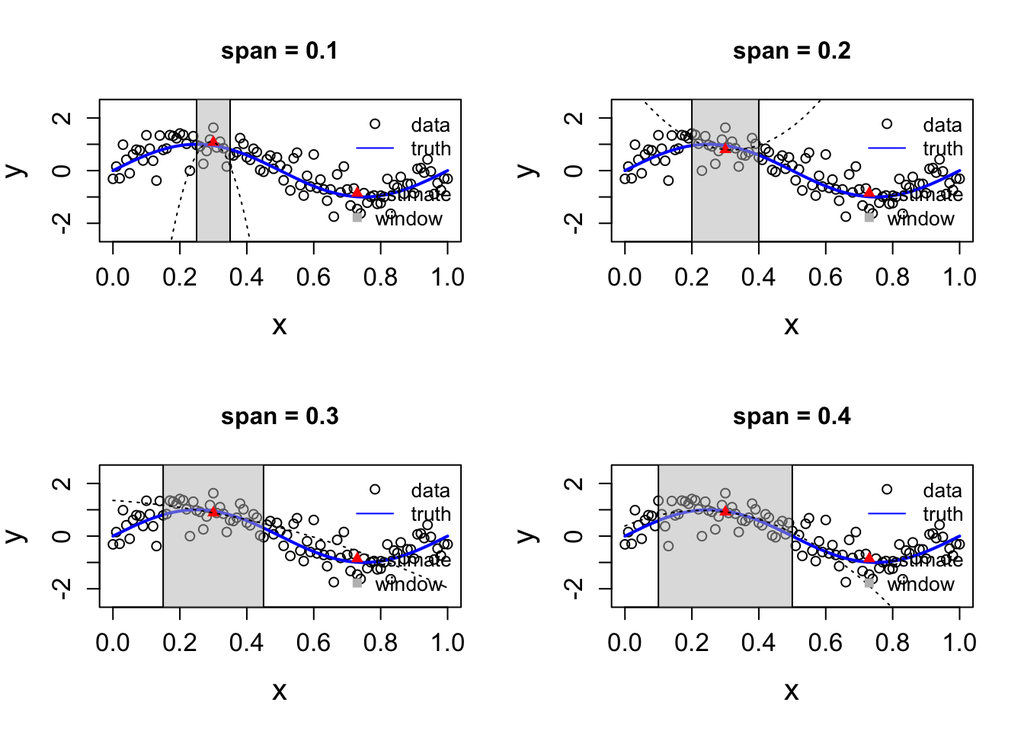

```r
# Local Quadratic Regression

# define function and data
set.seed(1)
n <- 101
x <- seq(0, 1, length.out = n)
fx <- sin(2 * pi * x)
y <- fx + rnorm(n, sd = 0.5)

# define x* and color for window
xstar <- 0.3
cols <- rgb(190/255,190/255,190/255,alpha=0.5)

# set-up 2 x 2 subplot
par(mfrow = c(2,2))

# loop through spans (0.1, 0.2, 0.3, 0.4)
for(s in c(0.1, 0.2, 0.3, 0.4)){

  # plot data and true function
  plot(x, y, main = paste0("span = ", s), ylim = c(-2.5, 2.5),
       cex.lab = 1.5, cex.axis = 1.25)
  lines(x, fx, col = "blue", lwd = 2)

  # plot window
  window <- c(xstar - s / 2, xstar + s / 2)
  rect(window[1], -3, window[2], 3, col = cols)

  # define weights
  w <- tricube(x - xstar, delta = s / 2)

  # plot estimate
  X <- cbind(1, x - 0.5, (x - 0.5)^2)
  X.w <- sqrt(w) * X
  y.w <- sqrt(w) * y
  beta <- solve(crossprod(X.w)) %*% crossprod(X.w, y.w)
  ystar <- as.numeric(cbind(1, xstar - 0.5, (xstar - 0.5)^2) %*% beta)
  points(xstar, ystar, pch = 17, col = "red", cex = 1)

  # add regression line
  lines(x, X %*% beta, lty = 3)

  # add legend
  legend("topright", legend = c("data", "truth"),
         pch = c(1, NA), lty = c(NA, 1), col = c("black", "blue"), bty = "n")
  legend("bottomright", legend = c("estimate", "window"),
         pch = c(17, 15), col = c("red", "gray"), bty = "n")

}
```

## 3.3 Selecting the Span

The **loess** function does not offer any data-driven method for selecting the span parameter. We can use LOOCV or GCV to select the span parameter.

The below function offers a simple implementation of the **loess** function that uses the GCV to tune the span parameter.

```r
loess.gcv <- function(x, y){
  nobs <- length(y)
  xs <- sort(x, index.return = TRUE)
  x <- xs$x
  y <- y[xs$ix]
  tune.loess <- function(s){
    lo <- loess(y ~ x, span = s)
    mean((lo$fitted - y)^2) / (1 - lo$trace.hat/nobs)^2
  }
  os <- optimize(tune.loess, interval = c(.01, 99))$minimum
  lo <- loess(y ~ x, span = os)
  list(x = x, y = lo$fitted, df = lo$trace.hat, span = os)
}
```

# 4 Kernel Regression

$$\hat{f}(x)=\sum_{i=1}^ny_iw_i(x),$$
where
$$w_i(x)=\frac{K([x-x_i]/h)}{\sum_{i=1}^n K([x-x_i]/h)},$$
with $K(\cdot)$ denoting some known kernel function (typically the Gaussian kernel), and $h>0$ denoting the bandwidth parameter. Note that the bandwidth parameter controls how much information from nearby $(x_i,y_i)$ points is used to estimate the function $f(\cdot)$ at the point $x$.

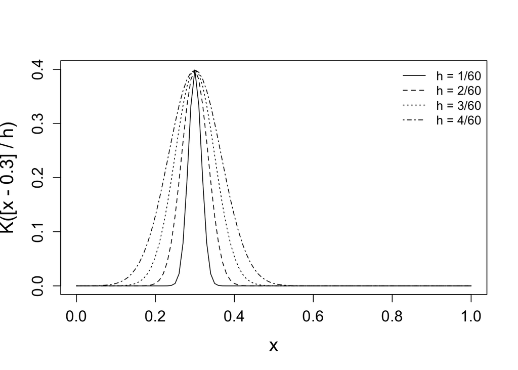

```r
# plot Gaussian kernel function
xstar <- 0.3
plot(x, dnorm((x - xstar) / (1 / 60)),
     t = "l", ylab = "K([x - 0.3] / h)", cex.lab = 1.5,
     cex.axis = 1.25, ylim = c(0, 0.4))
for(k in 2:4){
  lines(x, dnorm((x - xstar) / (k / 60)) , lty = k)
}
legend("topright", legend = c("h = 1/60", "h = 2/60", "h = 3/60", "h = 4/60"),
       lty = 1:4, bty = "n")
```

## 4.1 Simulation

To get an understanding of the kernel regression estimator, we will look at how the estimate is formed for the point $x^*=0.3$ using different values of the bandwidth parameter.

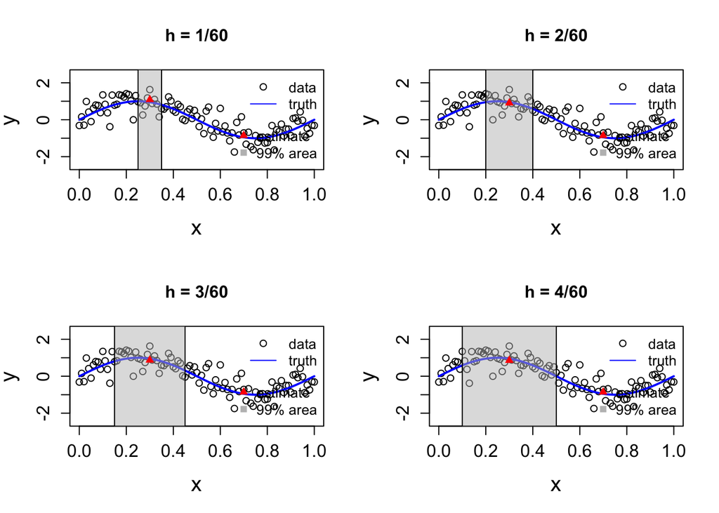

```r
# define function and data
set.seed(1)
n <- 101
x <- seq(0, 1, length.out = n)
fx <- sin(2 * pi * x)
y <- fx + rnorm(n, sd = 0.5)

# define x* and color for window
xstar <- 0.3
cols <- rgb(190/255, 190/255, 190/255, alpha = 0.5)

# set-up 2 x 2 subplot
par(mfrow = c(2,2))

# loop through h = c(1, 2, 3, 4) / 60
for(h in c(1:4)/60){

  # plot data and true function
  plot(x, y, main = paste0("h = ", h * 60, "/60"), ylim = c(-2.5, 2.5),
       cex.lab = 1.5, cex.axis = 1.25)
  lines(x, fx, col = "blue", lwd = 2)

  # plot 99% window
  window <- c(xstar - 3 * h, xstar + 3 * h)
  rect(window[1], -3, window[2], 3, col = cols)

  # define weights
  w <- dnorm((x - xstar) / h)
  w <- w / sum(w)

  # plot estimate
  ystar <- sum(y * w)
  points(xstar, ystar, pch = 17, col = "red", cex = 1)

  # add legend
  legend("topright", legend = c("data", "truth"),
         pch = c(1, NA), lty = c(NA, 1), col = c("black", "blue"), bty = "n")
  legend("bottomright", legend = c("estimate", "99% area"),
         pch = c(17, 15), col = c("red", "gray"), bty = "n")

}
```

## 4.2 Selecting the Bandwidth

Similar to the **loess** function, the **ksmooth** function does not offer any data-driven method for selecting the bandwidth parameter.

The below function offers a simple implementation of the **ksmooth function** (with Gaussian kernel) that uses the GCV to tune the bandwidth parameter.

```r
ksmooth.gcv <- function(x, y){
  nobs <- length(y)
  xs <- sort(x, index.return = TRUE)
  x <- xs$x
  y <- y[xs$ix]
  xdif <- outer(x, x, FUN = "-")
  tune.ksmooth <- function(h){
    xden <- dnorm(xdif / h)
    xden <- xden / rowSums(xden)
    df <- sum(diag(xden))
    fit <- xden %*% y
    mean((fit - y)^2) / (1 - df/nobs)^2
  }
  xrng <- diff(range(x))
  oh <- optimize(tune.ksmooth, interval = c(xrng/nobs, xrng))$minimum
  if(any(oh == c(xrng/nobs, xrng)))
    warning("Minimum found on boundary of search range.\nYou should retune model with expanded range.")
  xden <- dnorm(xdif / oh)
  xden <- xden / rowSums(xden)
  df <- sum(diag(xden))
  fit <- xden %*% y
  list(x = x, y = fit, df = df, h = oh)
}
```

# 5 Real-world Data Analysis

```r
# Example: Prestige from Income

# The Prestige dataset (from the car package) contains the prestige of n=102 Canadian occupations from 1971, as well as the average income of the occupation. We will use the nonparametric regression methods to explore the relationship between prestige and income.

# load data
library(car)
data(Prestige)
head(Prestige)
```

|  | education | income | women | prestige | census | type |
| --- | --- | --- | --- | --- | --- | --- |
| gov.administrators | 13.11 | 12351 | 11.16 | 68.8 | 1113 | prof |
| general.managers | 12.26 | 25879 | 4.02 | 69.1 | 1130 | prof |
| accountants | 12.77 | 9271 | 15.70 | 63.4 | 1171 | prof |
| purchasing.officers | 11.42 | 8865 | 9.11 | 56.8 | 1175 | prof |
| chemists | 14.62 | 8403 | 11.68 | 73.5 | 2111 | prof |
| physicists | 15.64 | 11030 | 5.13 | 77.6 | 2113 | prof |

```r
# plot data
plot(Prestige$income, Prestige$prestige,
     xlab = "Income", ylab = "Prestige")

# local averaging (cv span selection)
locavg <- with(Prestige, supsmu(income, prestige))

# local regression (gcv span selection)
locreg <- with(Prestige, loess.gcv(income, prestige))
locreg$df
```

```
## [1] 3.000201
```

```r
# kernel regression (gcv span selection)
kern <- with(Prestige, ksmooth.gcv(income, prestige))
kern$df
```

```
## [1] 8.00558
```

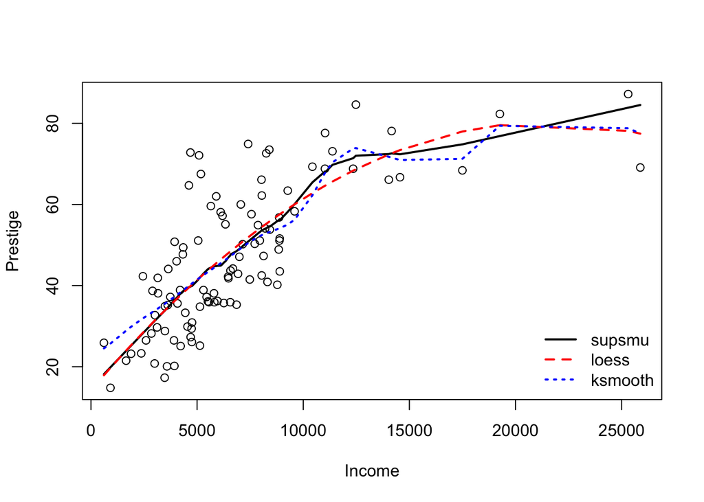

```r
# plot data
plot(Prestige$income, Prestige$prestige, xlab = "Income", ylab = "Prestige")

# add fit lines
lines(locavg, lwd = 2)
lines(locreg, lwd = 2, lty = 2, col = "red")
lines(kern, lwd = 2, lty = 3, col = "blue")

# add legend
legend("bottomright", c("supsmu", "loess", "ksmooth"),
       lty = 1:3, lwd = 2, col = c("black", "red", "blue"), bty = "n")
```